# R Notebook

## Non -linear models

```r
library(ISLR)
install.packages("Wage")
library(Wage)
```

```
Error in library(Wage) : there is no package called ‘Wage’
```

Polynomials

Response on age

```r
fit = lm(wage ~ poly(age, 4), data = Wage)
summary(fit)
```

```
Call:
lm(formula = wage ~ poly(age, 4), data = Wage)

Residuals:
    Min      1Q  Median      3Q     Max
-98.707 -24.626  -4.993  15.217 203.693

Coefficients:
               Estimate Std. Error t value Pr(>|t|)
(Intercept)    111.7036     0.7287 153.283  < 2e-16 ***
poly(age, 4)1  447.0679    39.9148  11.201  < 2e-16 ***
poly(age, 4)2 -478.3158    39.9148 -11.983  < 2e-16 ***
poly(age, 4)3  125.5217    39.9148   3.145  0.00168 **
poly(age, 4)4  -77.9112    39.9148  -1.952  0.05104 .
---
Signif. codes:  0 ‘***’ 0.001 ‘**’ 0.01 ‘*’ 0.05 ‘.’ 0.1 ‘ ’ 1

Residual standard error: 39.91 on 2995 degrees of freedom
Multiple R-squared:  0.08626,   Adjusted R-squared:  0.08504
F-statistic: 70.69 on 4 and 2995 DF,  p-value: < 2.2e-16
```

Plotting the polynomial fit

```r
agelims = range(age)
age.grid = seq(from = agelims[1], to = agelims[2])
preds = predict(fit, newdata = list(age = age.grid), se = TRUE)
#preds
se.bands = cbind(preds$fit + 2*preds$se, preds$fit - 2*preds$se)
plot(age, wage, col = "darkgrey")
lines(age.grid, preds$fit, lwd = 2, col = 'blue')
```

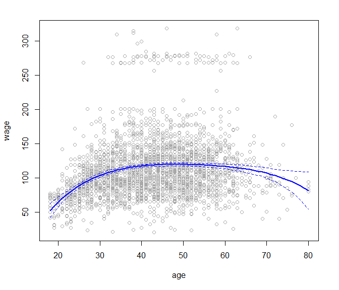

```r
matlines(age.grid, se.bands, col = 'blue', lty =2)
```

LM without the poly function

```r
fita = lm(wage ~ age + I(age^2) + I(age^3) + I(age^4), data = Wage)
summary(fita)
```

```
Call:
lm(formula = wage ~ age + I(age^2) + I(age^3) + I(age^4), data = Wage)

Residuals:
    Min      1Q  Median      3Q     Max
-98.707 -24.626  -4.993  15.217 203.693

Coefficients:
              Estimate Std. Error t value Pr(>|t|)
(Intercept) -1.842e+02  6.004e+01  -3.067 0.002180 **
age          2.125e+01  5.887e+00   3.609 0.000312 ***
I(age^2)    -5.639e-01  2.061e-01  -2.736 0.006261 **
I(age^3)     6.811e-03  3.066e-03   2.221 0.026398 *
I(age^4)    -3.204e-05  1.641e-05  -1.952 0.051039 .
---
Signif. codes:  0 ‘***’ 0.001 ‘**’ 0.01 ‘*’ 0.05 ‘.’ 0.1 ‘ ’ 1

Residual standard error: 39.91 on 2995 degrees of freedom
Multiple R-squared:  0.08626,   Adjusted R-squared:  0.08504
F-statistic: 70.69 on 4 and 2995 DF,  p-value: < 2.2e-16
```

The p-values changes as polynomial function changed

[figure not shown]

This only works with linear regression and if there is a single predictor. To compare two models, we would need anova

```r
summary(fit)
```

```
Call:
lm(formula = wage ~ poly(age, 4), data = Wage)

Residuals:
    Min      1Q  Median      3Q     Max
-98.707 -24.626  -4.993  15.217 203.693

Coefficients:
               Estimate Std. Error t value Pr(>|t|)
(Intercept)    111.7036     0.7287 153.283  < 2e-16 ***
poly(age, 4)1  447.0679    39.9148  11.201  < 2e-16 ***
poly(age, 4)2 -478.3158    39.9148 -11.983  < 2e-16 ***
poly(age, 4)3  125.5217    39.9148   3.145  0.00168 **
poly(age, 4)4  -77.9112    39.9148  -1.952  0.05104 .
---
Signif. codes:  0 ‘***’ 0.001 ‘**’ 0.01 ‘*’ 0.05 ‘.’ 0.1 ‘ ’ 1

Residual standard error: 39.91 on 2995 degrees of freedom
Multiple R-squared:  0.08626,   Adjusted R-squared:  0.08504
F-statistic: 70.69 on 4 and 2995 DF,  p-value: < 2.2e-16
```

```r
fita=lm(wage~education,data=Wage)
fitb=lm(wage~education+age,data=Wage)
fitc=lm(wage~education+poly(age,2),data=Wage)
fitd=lm(wage~education+poly(age,3),data=Wage)
anova(fita,fitb,fitc,fitd)
```

```
Analysis of Variance Table

Model 1: wage ~ education
Model 2: wage ~ education + age
Model 3: wage ~ education + poly(age, 2)
Model 4: wage ~ education + poly(age, 3)
  Res.Df     RSS Df Sum of Sq        F Pr(>F)
1   2995 3995721
2   2994 3867992  1    127729 102.7378 <2e-16 ***
3   2993 3725395  1    142597 114.6969 <2e-16 ***
4   2992 3719809  1      5587   4.4936 0.0341 *
---
Signif. codes:  0 ‘***’ 0.001 ‘**’ 0.01 ‘*’ 0.05 ‘.’ 0.1 ‘ ’ 1
```

# Polynomial Logistic regression

```r
fit = glm(I(wage > 250) ~ poly(age, 3), data = Wage, family = binomial)
summary(fit)
```

```
Call:
glm(formula = I(wage > 250) ~ poly(age, 3), family = binomial,
    data = Wage)

Deviance Residuals:
    Min       1Q   Median       3Q      Max
-0.2808  -0.2736  -0.2487  -0.1758   3.2868

Coefficients:
              Estimate Std. Error z value Pr(>|z|)
(Intercept)    -3.8486     0.1597 -24.100  < 2e-16 ***
poly(age, 3)1  37.8846    11.4818   3.300 0.000968 ***
poly(age, 3)2 -29.5129    10.5626  -2.794 0.005205 **
poly(age, 3)3   9.7966     8.9990   1.089 0.276317
---
Signif. codes:  0 ‘***’ 0.001 ‘**’ 0.01 ‘*’ 0.05 ‘.’ 0.1 ‘ ’ 1

(Dispersion parameter for binomial family taken to be 1)

    Null deviance: 730.53  on 2999  degrees of freedom
Residual deviance: 707.92  on 2996  degrees of freedom
AIC: 715.92

Number of Fisher Scoring iterations: 8
```

```r
preds = predict(fit, newdata = list(age = age.grid), se = TRUE)
se.bands = preds$fit + cbind(fit =0, lower = - 2*preds$se, upper = 2*preds$se)
se.bands[1:5,]
```

```
        fit      lower     upper
1 -7.664756 -10.759826 -4.569686
2 -7.324776 -10.106699 -4.542852
3 -7.001732  -9.492821 -4.510643
4 -6.695229  -8.917158 -4.473300
5 -6.404868  -8.378691 -4.431045
```

We have done the computations on the logit scale. To transform we need to apply the inverse logit mapping
$$p=\frac{e^\eta}{1+e^\eta}.$$
(Here we have used the ability of MarkDown to interpret TeX expressions.) We can do this simultaneously for all three columns of `se.bands`:

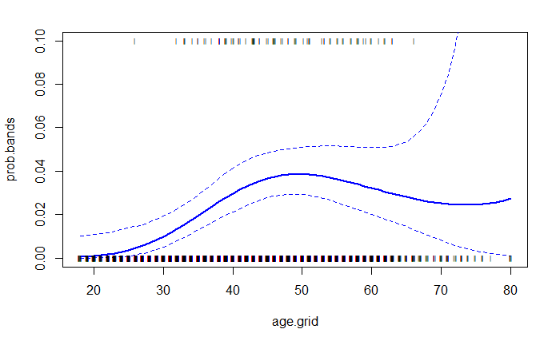

```r
prob.bands = exp(se.bands)/(1 + exp(se.bands))
matplot(age.grid,prob.bands,col="blue",lwd=c(2,1,1),lty=c(1,2,2),type="l",ylim=c(0,.1))
points(jitter(age),I(wage>250)/10,pch="|",cex=.5)
```

## Splines

Splines are more flexible than polynomials, but the idea is rather similar. Here we will explore cubic splines.

```r
library(splines)
fit = lm(wage ~ bs(age, knots = c(25,40,60)), data = Wage)
summary(fit)
```

```
Call:
lm(formula = wage ~ bs(age, knots = c(25, 40, 60)), data = Wage)

Residuals:
    Min      1Q  Median      3Q     Max
-98.832 -24.537  -5.049  15.209 203.207

Coefficients:
                                Estimate Std. Error t value Pr(>|t|)
(Intercept)                       60.494      9.460   6.394 1.86e-10 ***
bs(age, knots = c(25, 40, 60))1    3.980     12.538   0.317 0.750899
bs(age, knots = c(25, 40, 60))2   44.631      9.626   4.636 3.70e-06 ***
bs(age, knots = c(25, 40, 60))3   62.839     10.755   5.843 5.69e-09 ***
bs(age, knots = c(25, 40, 60))4   55.991     10.706   5.230 1.81e-07 ***
bs(age, knots = c(25, 40, 60))5   50.688     14.402   3.520 0.000439 ***
bs(age, knots = c(25, 40, 60))6   16.606     19.126   0.868 0.385338
---
Signif. codes:  0 ‘***’ 0.001 ‘**’ 0.01 ‘*’ 0.05 ‘.’ 0.1 ‘ ’ 1

Residual standard error: 39.92 on 2993 degrees of freedom
Multiple R-squared:  0.08642,   Adjusted R-squared:  0.08459
F-statistic: 47.19 on 6 and 2993 DF,  p-value: < 2.2e-16
```

```r
plot(age, wage, col = "darkgrey")
lines(age.grid,predict(fit,list(age=age.grid)),col="darkgreen",lwd=2)
```

```r
abline(v=c(25,40,60),lty=2,col="darkgreen")
#smoothing spline
fit = smooth.spline(age, wage, df = 16)
lines(fit, col = "red", lwd =2)
```

```r
#LOOCV
fit = smooth.spline(age, wage, cv = TRUE)
```

```
cross-validation with non-unique 'x' values seems doubtful
```

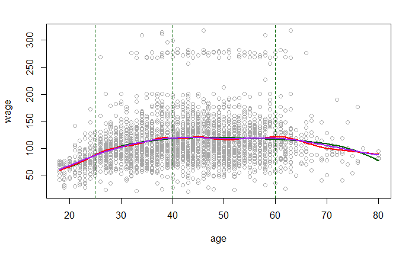

```r
lines(fit, col = 'purple', lwd = 2)
```

```r
fit
```

```
Call:
smooth.spline(x = age, y = wage, cv = TRUE)

Smoothing Parameter  spar= 0.6988943  lambda= 0.02792303 (12 iterations)
Equivalent Degrees of Freedom (Df): 6.794596
Penalized Criterion (RSS): 75215.9
PRESS(l.o.o. CV): 1593.383
```

The smoothing splines does not require knot selection, but it does have a smoothing parameter, which can conveniently be specified via the effective degrees of freedom or `df`.

```r
fit = smooth.spline(age, wage, df = 16)
lines(fit, col = "red", lwd =2)
```

```
Error in plot.xy(xy.coords(x, y), type = type, ...) :
  plot.new has not been called yet
```

Using LOO cross-validation

```r
fit = smooth.spline(age, wage, cv = TRUE)
lines(fit, col = 'purple', lwd = 2)
fit
```

[output not shown]

## Generalized Additive Models

So far we have focused on fitting models with mostly single nonlinear terms. The `gam` package makes it easier to work with multiple nonlinear terms. In addition it knows how to plot these functions and their standard errors.

```r
install.packages("gam")
```

```
Error in install.packages : Updating loaded packages
```

```r
require(gam)
gam1 = gam(wage ~ s(age, df=4) + s(year, df =4) + education, data = Wage)
summary(gam1)
```

```
Call: gam(formula = wage ~ s(age, df = 4) + s(year, df = 4) + education,
    data = Wage)
Deviance Residuals:
     Min       1Q   Median       3Q      Max
-118.941  -19.657   -3.328   14.058  213.456

(Dispersion Parameter for gaussian family taken to be 1236.299)

    Null Deviance: 5222086 on 2999 degrees of freedom
Residual Deviance: 3692824 on 2987 degrees of freedom
AIC: 29888.23

Number of Local Scoring Iterations: 2

Anova for Parametric Effects
                  Df  Sum Sq Mean Sq F value    Pr(>F)
s(age, df = 4)     1  200673  200673 162.317 < 2.2e-16 ***
s(year, df = 4)    1   21446   21446  17.347 3.202e-05 ***
education          4 1073411  268353 217.061 < 2.2e-16 ***
Residuals       2987 3692824    1236
---
Signif. codes:  0 ‘***’ 0.001 ‘**’ 0.01 ‘*’ 0.05 ‘.’ 0.1 ‘ ’ 1

Anova for Nonparametric Effects
                Npar Df Npar F  Pr(F)
(Intercept)
s(age, df = 4)        3 42.318 <2e-16 ***
s(year, df = 4)       3  1.079 0.3568
education
---
Signif. codes:  0 ‘***’ 0.001 ‘**’ 0.01 ‘*’ 0.05 ‘.’ 0.1 ‘ ’ 1
```

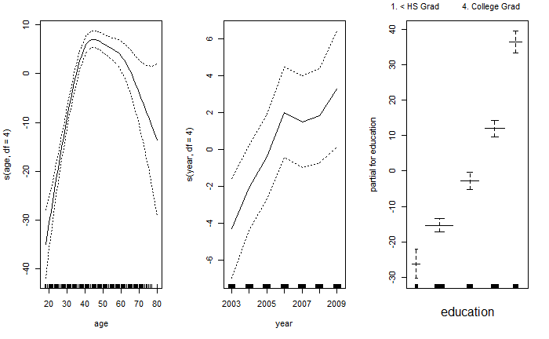

```r
par(mfrow=c(1,3))
plot(gam1,se=T)
```

```r
gam2=gam(I(wage>250)~s(age,df=4)+s(year,df=4)+education,data=Wage,family=binomial)
gam2
```

```
Call:
gam(formula = I(wage > 250) ~ s(age, df = 4) + s(year, df = 4) +
    education, family = binomial, data = Wage)

Degrees of Freedom: 2999 total; 2987 Residual
Residual Deviance: 602.8724
```

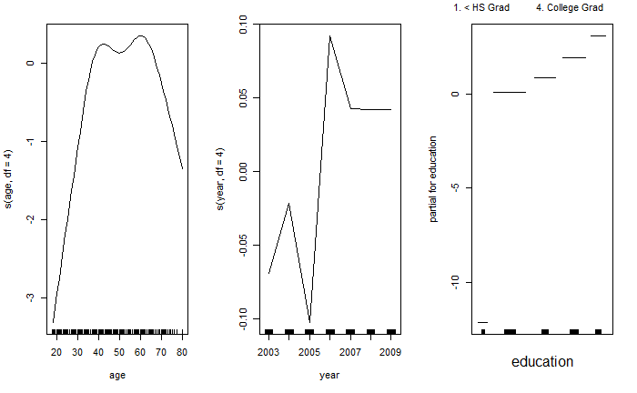

```r
plot(gam2)
```

Lets see if we need a nonlinear terms for year

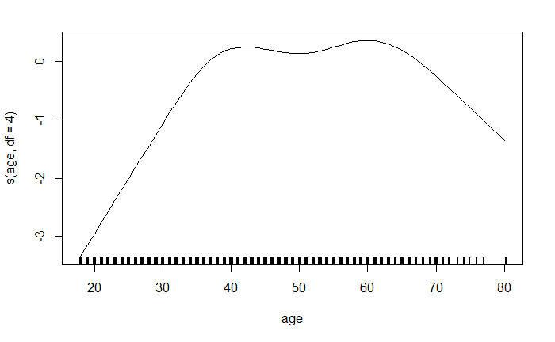

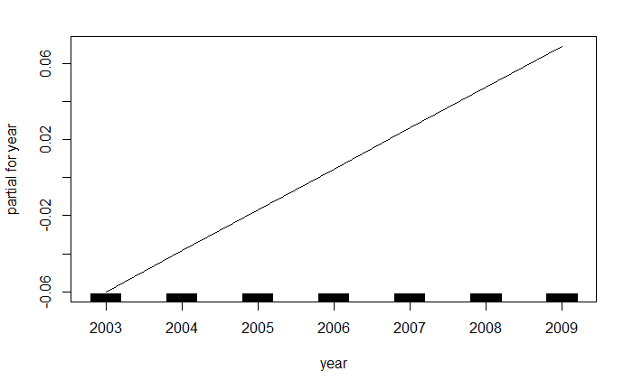

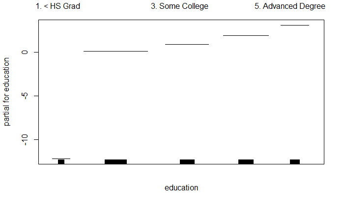

```r
gam2a = gam(I(wage > 250) ~ s(age, df = 4) + year +education, data = Wage, family = binomial)
plot(gam2a)
```

```r
anova(gam2a, gam2, test = "Chisq")
```

```
Analysis of Deviance Table

Model 1: I(wage > 250) ~ s(age, df = 4) + year + education
Model 2: I(wage > 250) ~ s(age, df = 4) + s(year, df = 4) + education
  Resid. Df Resid. Dev Df Deviance Pr(>Chi)
1      2990     603.78
2      2987     602.87  3  0.90498   0.8242
```

One nice feature of the `gam` package is that it knows how to plot the functions nicely, even for models fit by `lm` and `glm`.

```r
library(gam)
par(mfrow=c(1,3))
lm1=lm(wage~ns(age,df=4)+ns(year,df=4)+education,data=Wage)
plot.gam(lm1,se=T)
```

```
Error in plot.gam(lm1, se = T) : could not find function "plot.gam"
```